# Sex Differences

Raphael Q. Gastrock

2026-05-04

This document contains analyses for comparing males and females across our behavioral and EEG results.

```r
source('ana/shared.R')
source('ana/learningRates.R')
source('ana/permutationTtest.R')
source('ana/movementAnalyses.R')
```

# Behavioral analyses

First we confirm the absence of any sex effects across all our behavioral measures, similar to our earlier study (Gastrock et al., 2024).

## Learning (Compensation)

We compare the amount of compensation throughout all trials of training in each perturbation type. We do not perform exhaustive statistical tests for these comparisons. Instead, we present means and 95% confidence intervals for us to get a qualitative sense of any differences between the two sexes.

### Fixed rotation

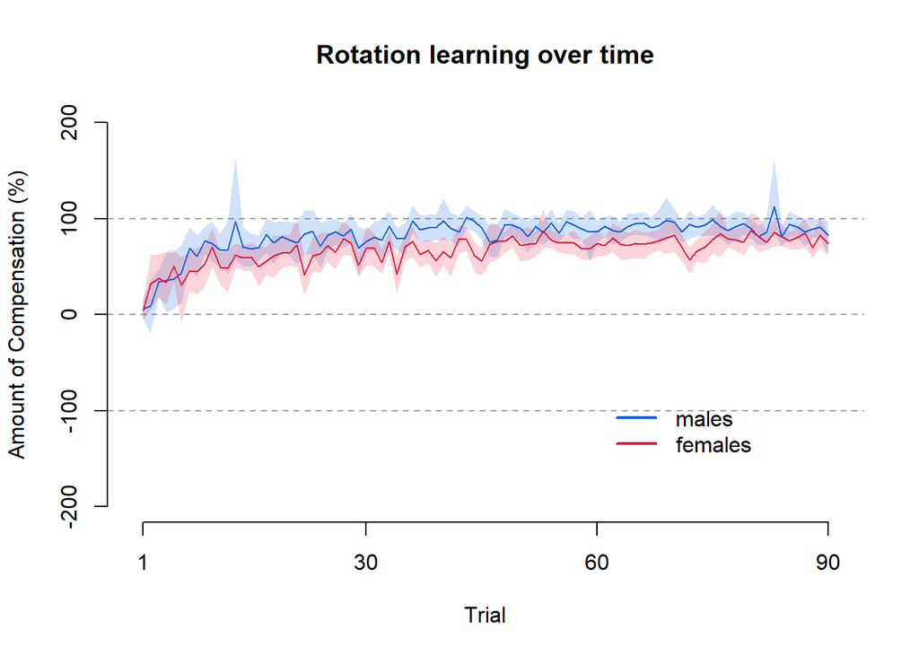

```r
plotSexROTLearningCurves()
```

For the most part, especially during earlier and later training, means in one sex overlap the confidence interval range of the other sex, suggesting no overall differences in compensation.

### Mirror reversal

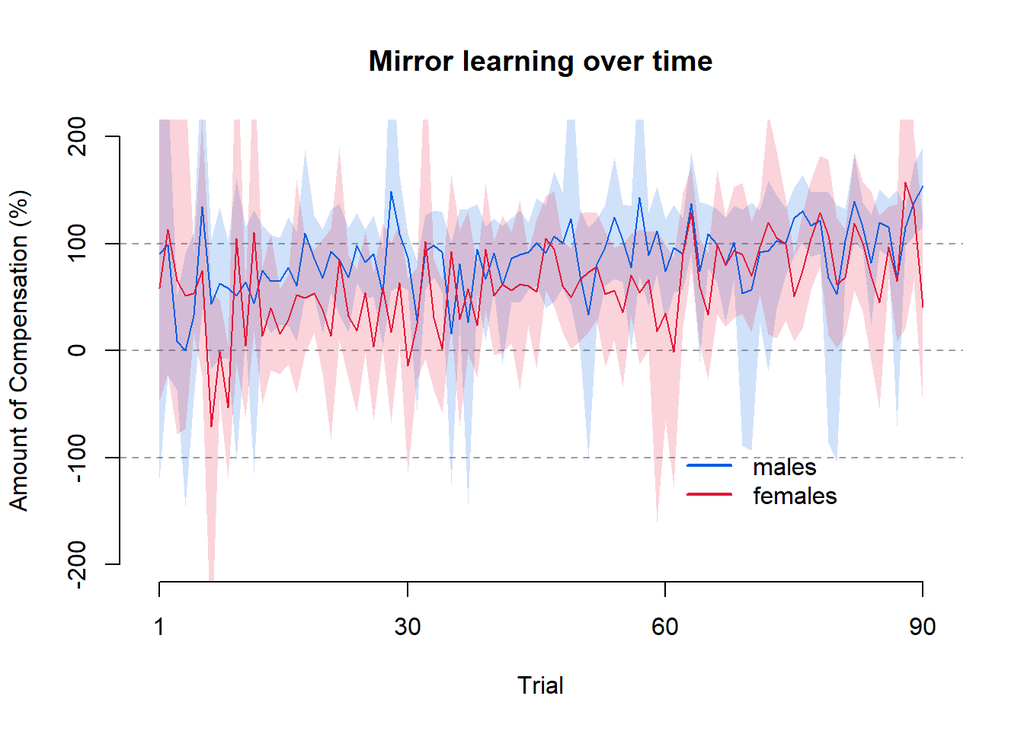

```r
plotSexMIRLearningCurves()
```

No overall differences, but we do note higher variability across participants.

### Random rotation: Sets 1 and 2

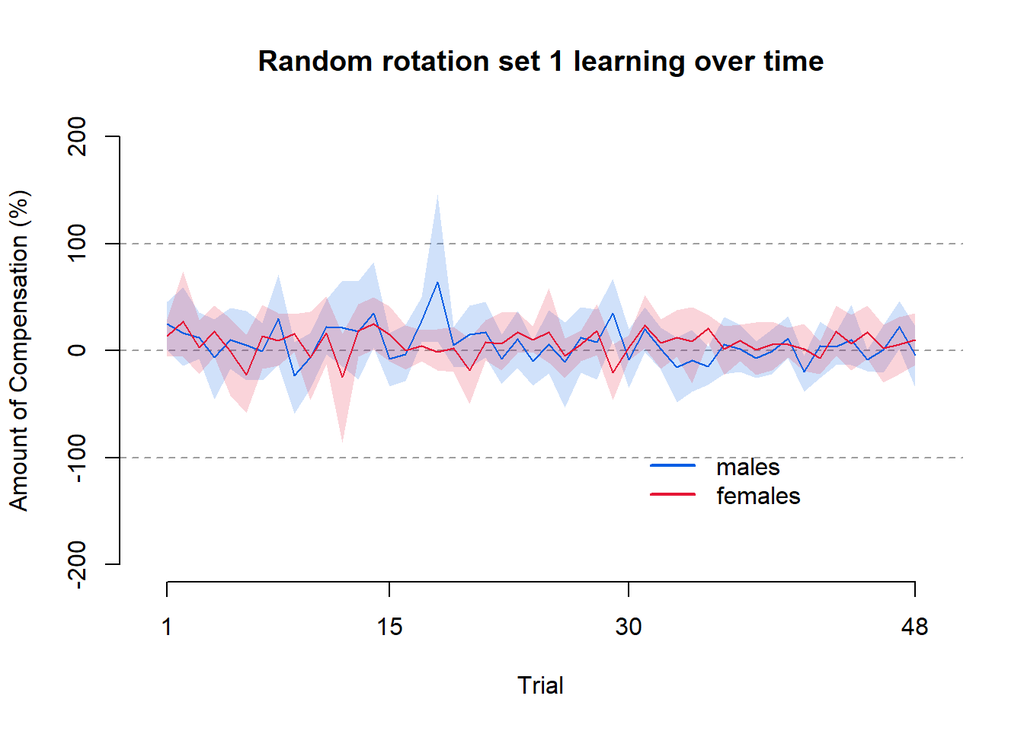

```r
plotSexRDM1LearningCurves()
```

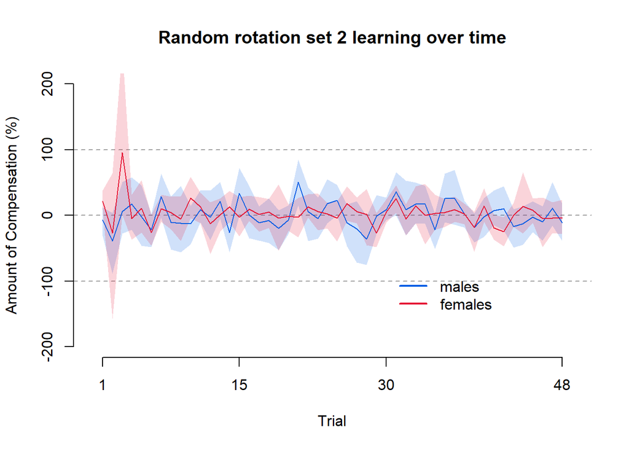

```r
plotSexRDM2LearningCurves()
```

No overall differences between males and females. We also observe no learning for this perturbation type.

## Movement measures

We then compare males and females along different movement variables (reaction time, movement time, path length), during different trial types (aligned, random rotation prior each perturbation training, perturbation training),

Trial types proceed in the following manner for plots below: aligned > random rotation set 1 > fixed rotation > random rotation set 2 > mirror reversal

### Reaction times

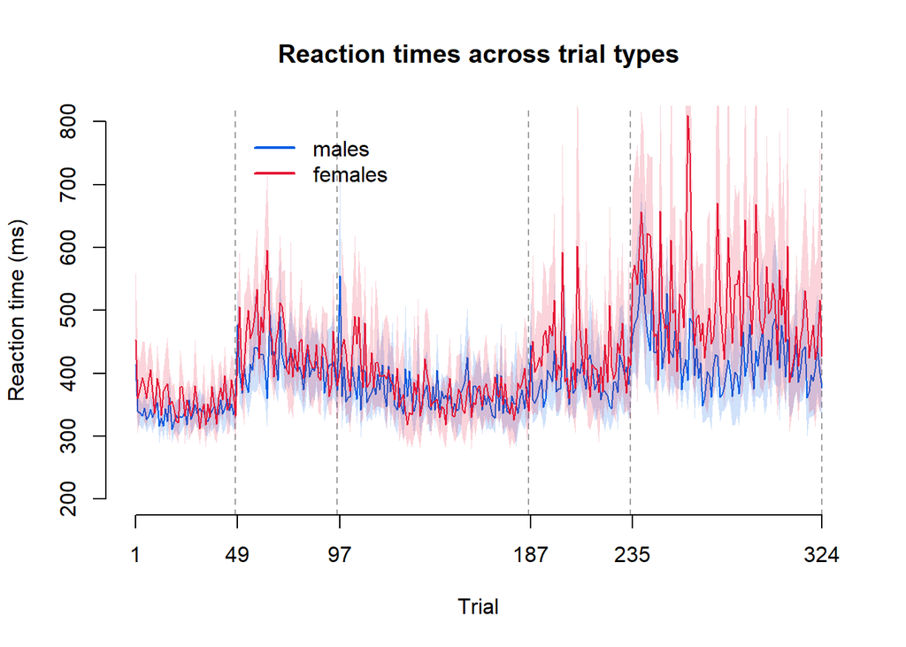

```r
plotSexRTs()
```

```r
sexRTBayesANOVA()
```

```
## Reaction times, males versus females:
## Bayes factor analysis
## --------------
## [1] set + participant                 : 2.217481e+30 ±0.26%
## [2] sex + participant                 : 1.18358      ±0.89%
## [3] set + sex + participant           : 2.976871e+30 ±1.45%
## [4] set + sex + set:sex + participant : 4.408467e+28 ±7.63%
##
## Against denominator:
##   dv ~ participant
## ---
## Bayes factor type: BFlinearModel, JZS
##
## Inclusion Bayes Factors (Model Averaged)
##
##             P(prior) P(posterior) Inclusion BF
## participant     1.00         1.00
## set             0.60         1.00     1.60e+30
## sex             0.60         0.58        0.908
## set:sex         0.20     8.42e-03        0.034
##
## * Compared among: all models
## *    Priors odds: uniform-equal
```

We find no evidence for an effect of sex.

### Movement times

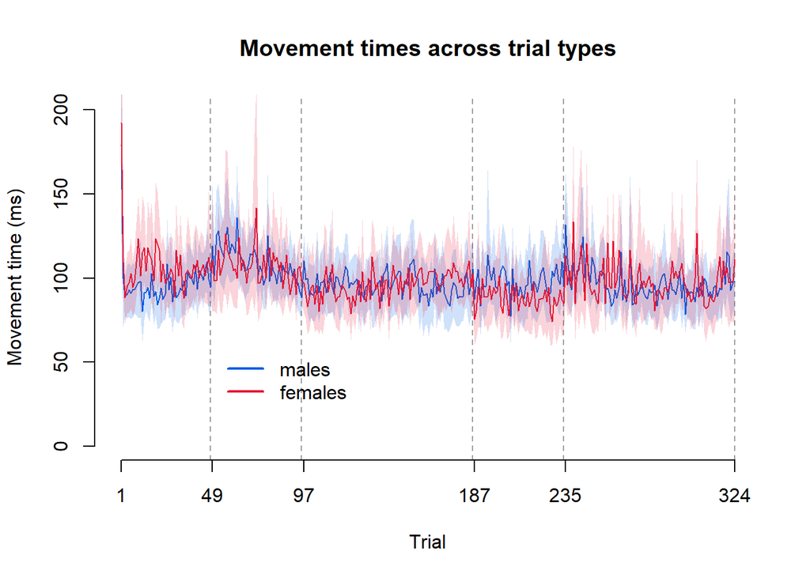

```r
plotSexMTs()
```

```r
sexMTBayesANOVA()
```

```
## Movement times, males versus females:
## Bayes factor analysis
## --------------
## [1] set + participant                 : 0.5900675   ±0.21%
## [2] sex + participant                 : 0.3597814   ±0.56%
## [3] set + sex + participant           : 0.2174153   ±0.63%
## [4] set + sex + set:sex + participant : 0.004056212 ±0.72%
##
## Against denominator:
##   dv ~ participant
## ---
## Bayes factor type: BFlinearModel, JZS
##
## Inclusion Bayes Factors (Model Averaged)
##
##             P(prior) P(posterior) Inclusion BF
## participant     1.00         1.00
## set             0.60         0.37        0.398
## sex             0.60         0.27        0.244
## set:sex         0.20     1.87e-03        0.007
##
## * Compared among: all models
## *    Priors odds: uniform-equal
```

We find no evidence for an effect of sex.

### Path length

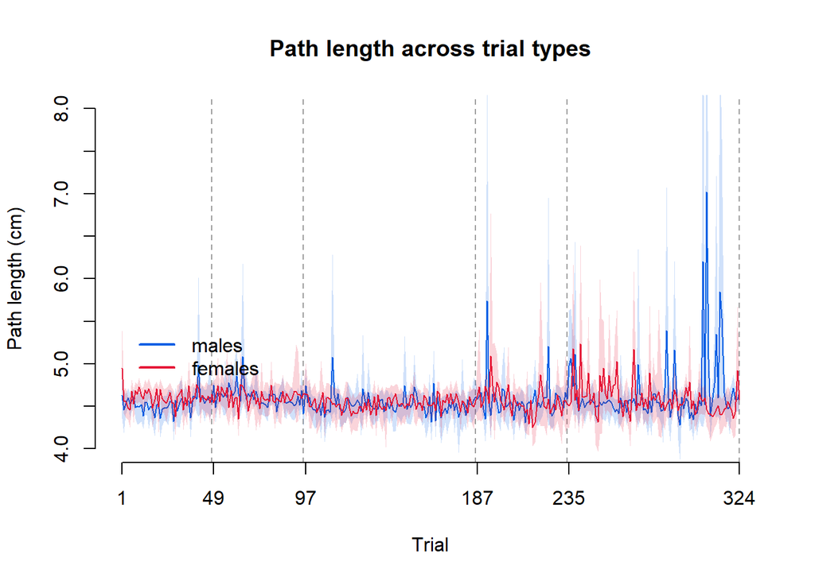

```r
plotSexPLs()
```

```r
sexPLBayesANOVA()
```

```
## Path lengths, males versus females:
## Bayes factor analysis
## --------------
## [1] set + participant                 : 0.05489968   ±0.16%
## [2] sex + participant                 : 0.2706415    ±1.29%
## [3] set + sex + participant           : 0.01493429   ±1.37%
## [4] set + sex + set:sex + participant : 0.0004821699 ±0.7%
##
## Against denominator:
##   dv ~ participant
## ---
## Bayes factor type: BFlinearModel, JZS
##
## Inclusion Bayes Factors (Model Averaged)
##
##             P(prior) P(posterior) Inclusion BF
## participant     1.00         1.00
## set             0.60         0.05        0.037
## sex             0.60         0.21        0.181
## set:sex         0.20     3.60e-04        0.001
##
## * Compared among: all models
## *    Priors odds: uniform-equal
```

We find no evidence for an effect of sex.

## General Conclusions

Overall, we do not find evidence for differences between males and females for our different behavioral measures.

# EEG Analyses

Given that we implemented our EEG analyses in steps (1: each condition’s difference with aligned, 2: early vs late and small versus large, 3: across perturbation types), comparing males and females across all these steps will produce a comprehensive set of results. Therefore, for the results below, we will only focus sex comparisons within each perturbation type, after subtracting Late minus Early and Small minus Large conditions. As in our main results, we compare EEG signals between males and females using cluster-based permutation t tests. Identified clusters will be highlighter as light purple bars in the plots below, but significant clusters will be in solid purple bars.

## Temporal domain

### Movement preparation

#### Early-late difference

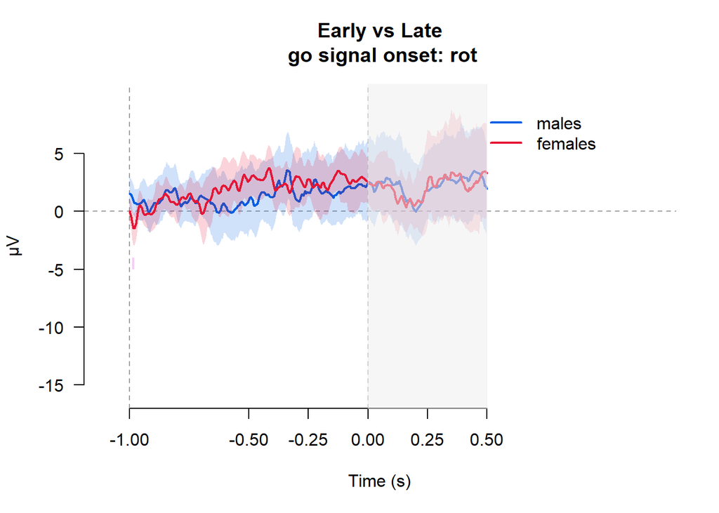

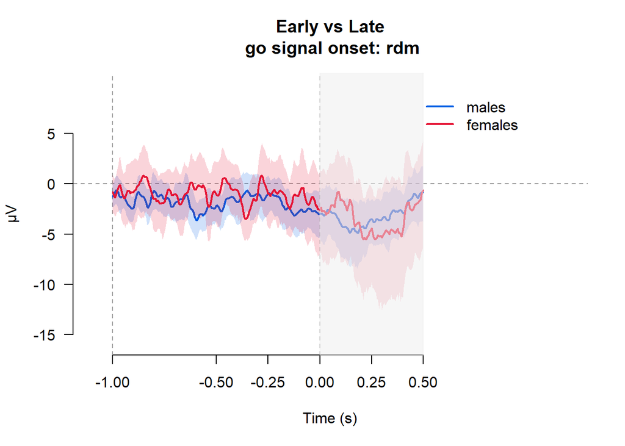

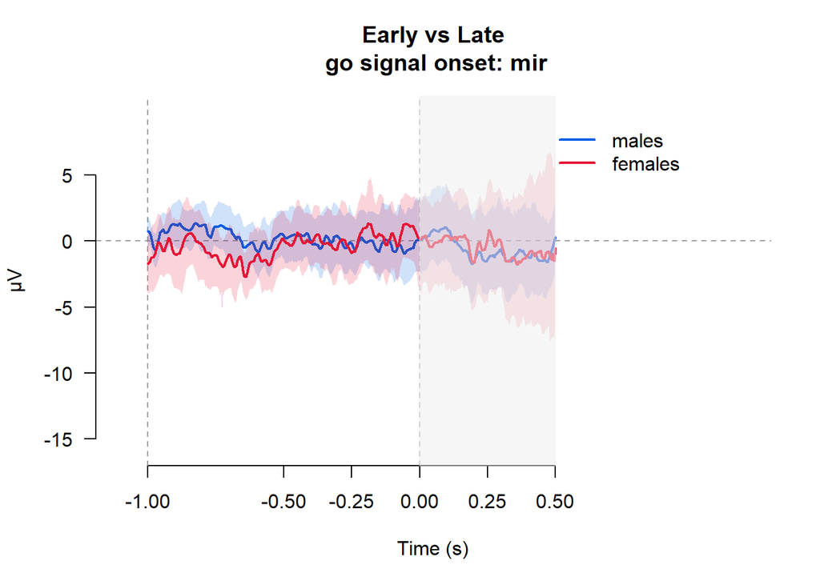

```r
plotSexPTypeRPPermTestEarlyLateDiffWaves()
```

No significant clusters identified.

#### Small-large difference

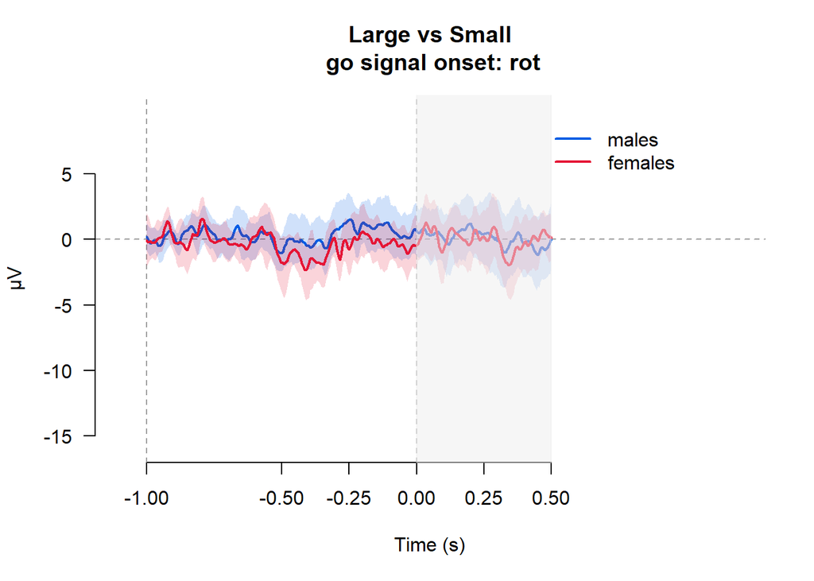

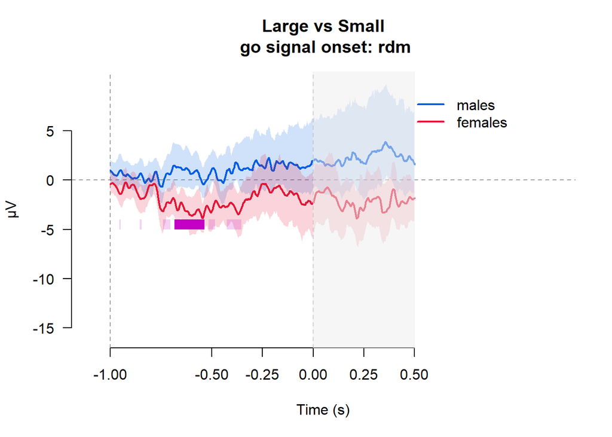

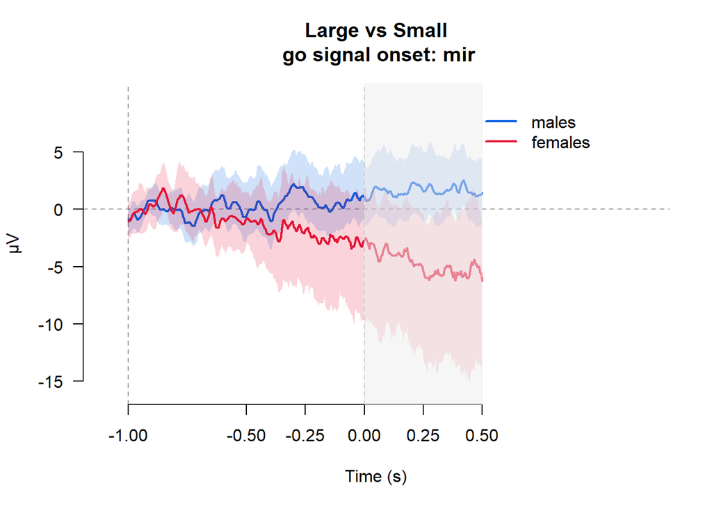

```r
plotSexPTypeRPPermTestSmallLargeDiffWaves()
```

We find a significant cluster for the random rotation condition (-0.69 to -0.54 sec), where the signal is more negative for females than males. This suggests that RPs were more negative for large errors compared to small errors in females, which was not the case for males. However, we note that despite this difference in RPs, we do not find overall differences in behavior between males and females.

### Feedback processing

#### Early-late difference

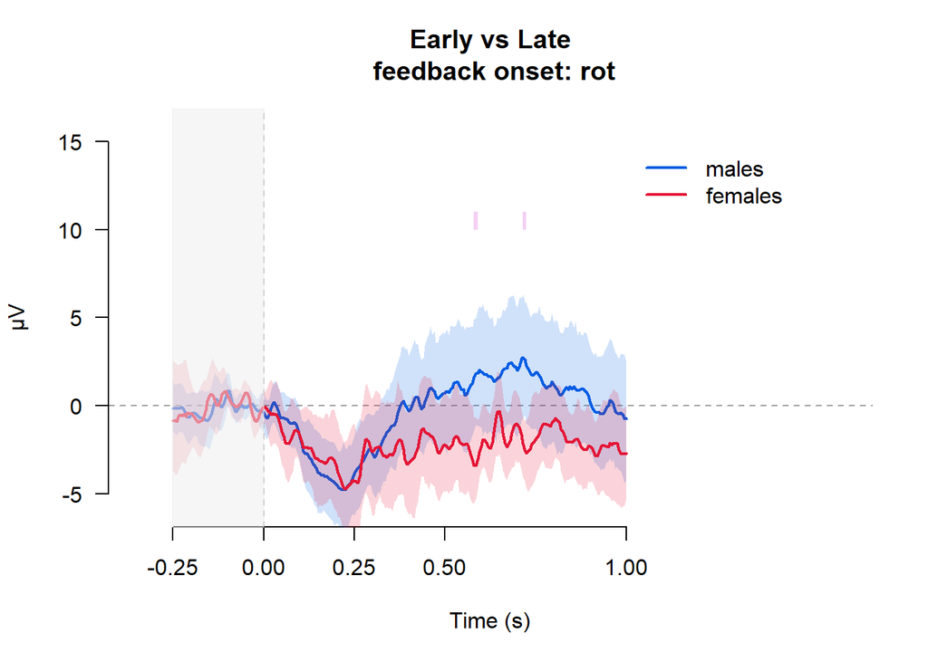

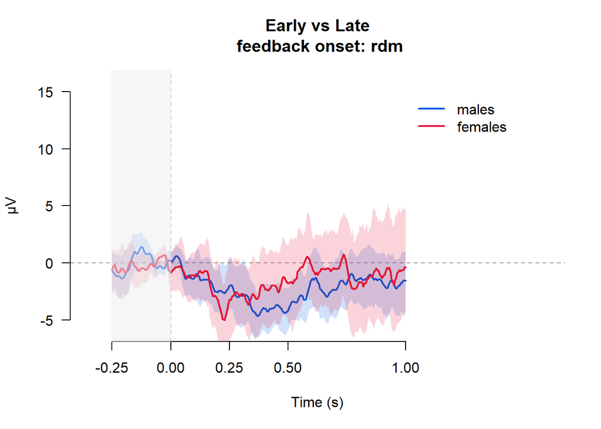

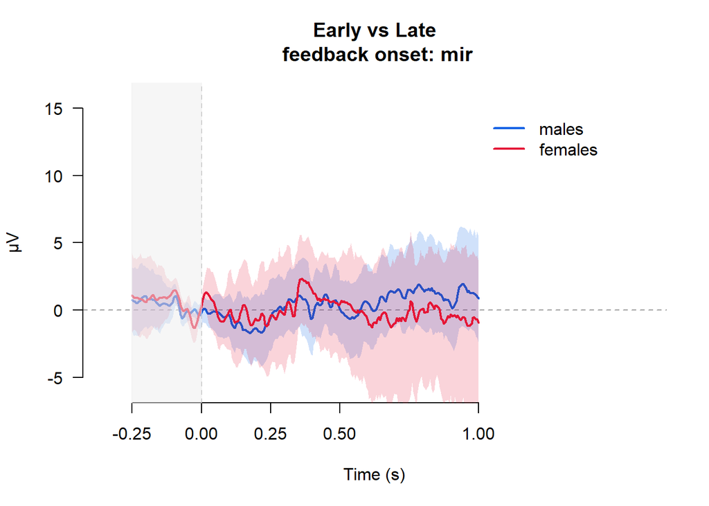

```r
plotSexPTypeFRNPermTestEarlyLateDiffWaves()
```

No significant clusters identified.

#### Small-large difference

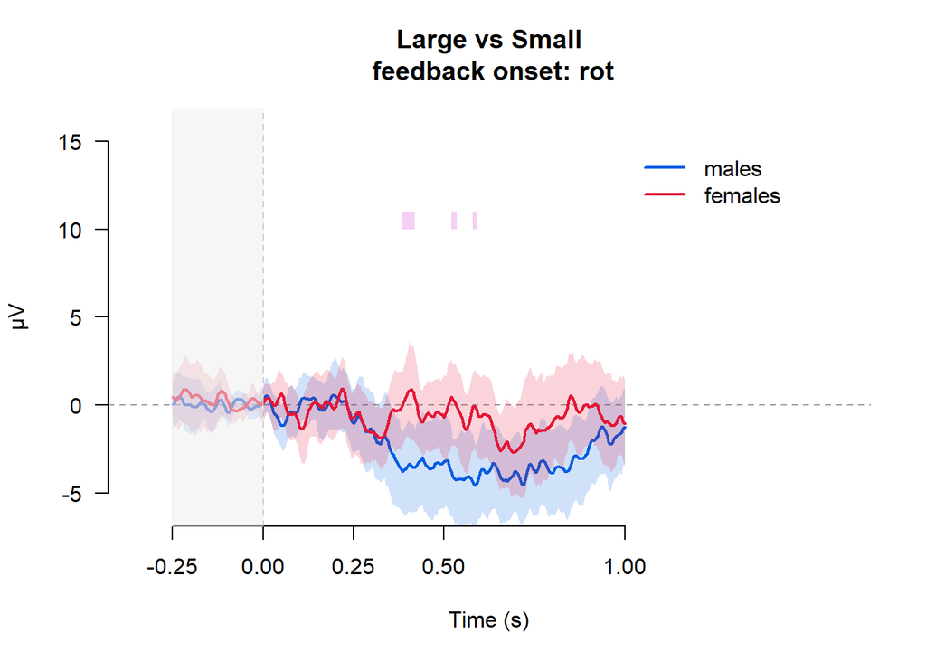

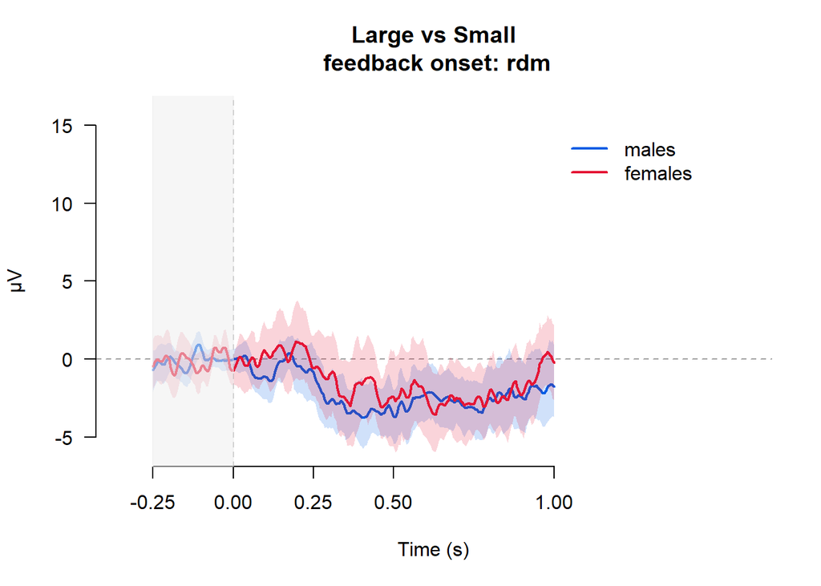

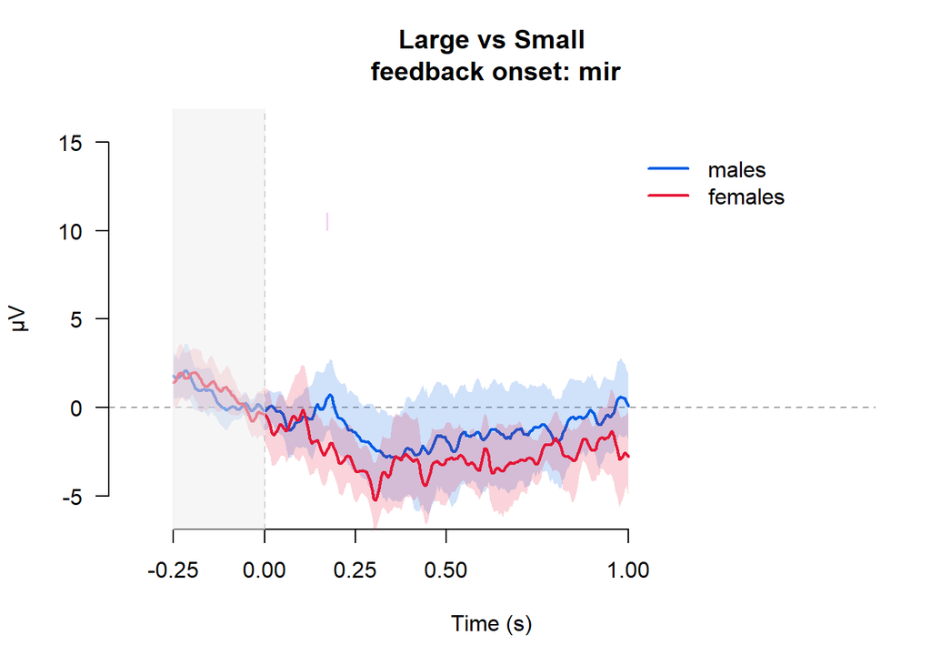

```r
plotSexPTypeFRNPermTestSmallLargeDiffWaves()
```

No significant clusters identified.

## Frequency domain

We repeat the same analyses as in the temporal domain, but also compare across our predetermined ROIs and across beta, alpha, and theta frequency bands.

### Movement preparation

#### Early-late difference

##### medial frontal region

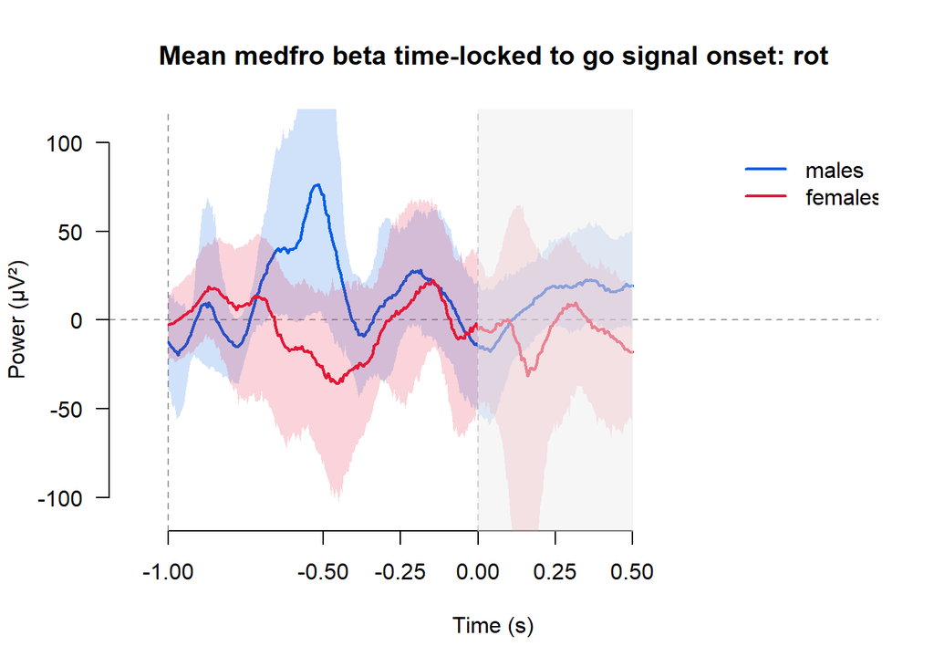

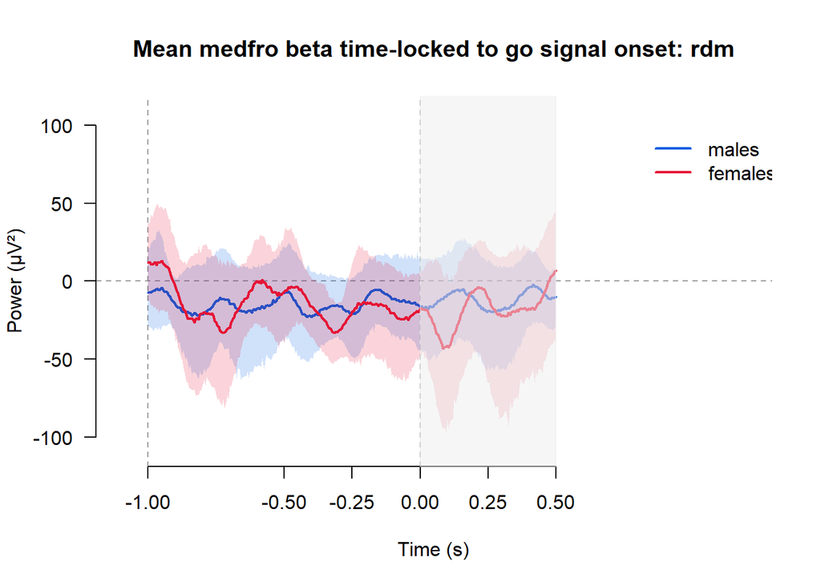

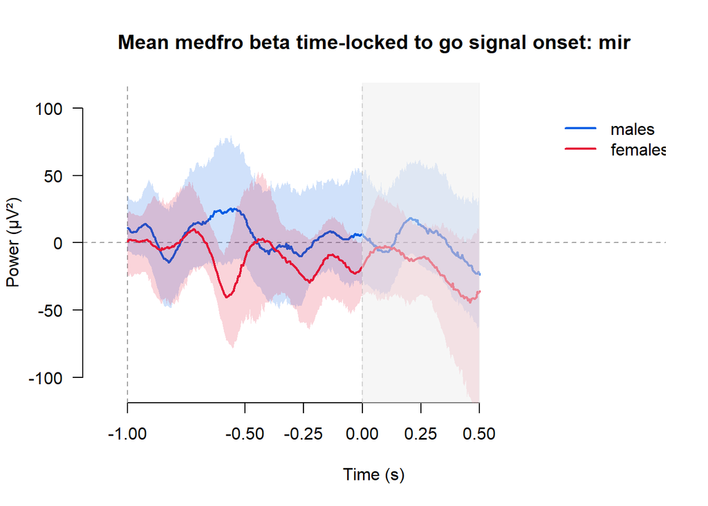

```r
plotSexPTypeTFRRPPermTestEarlyLateDiffWaves(freqs = 'beta', roi = 'medfro')
```

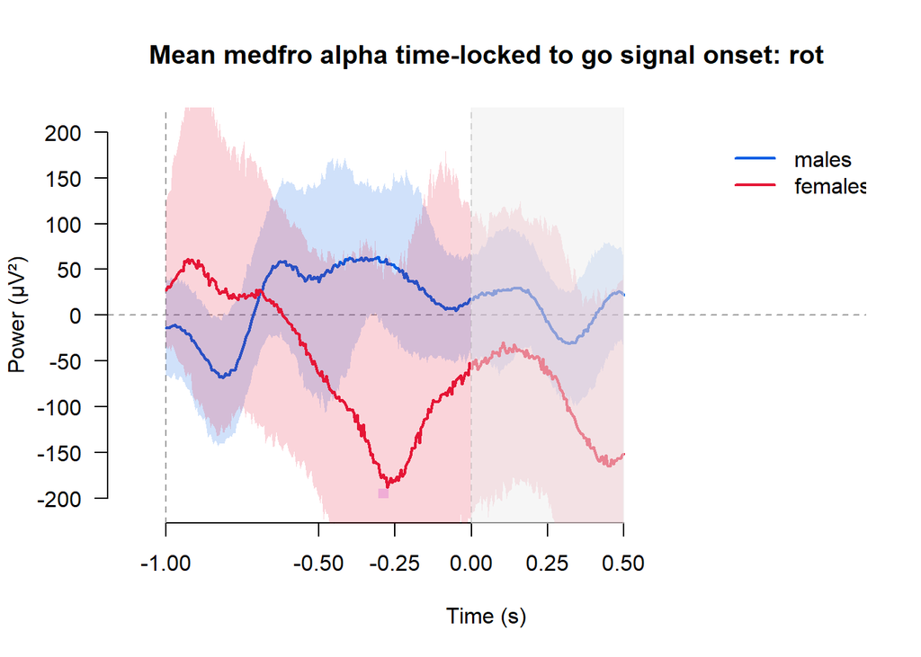

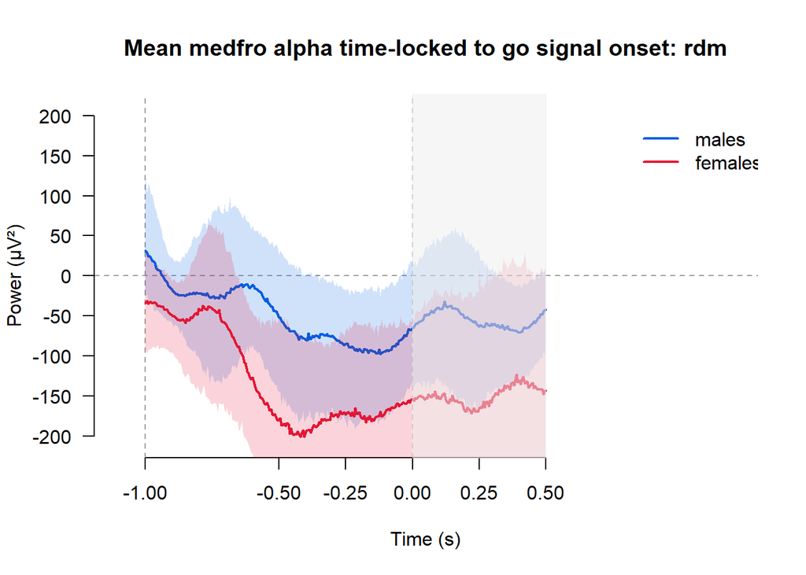

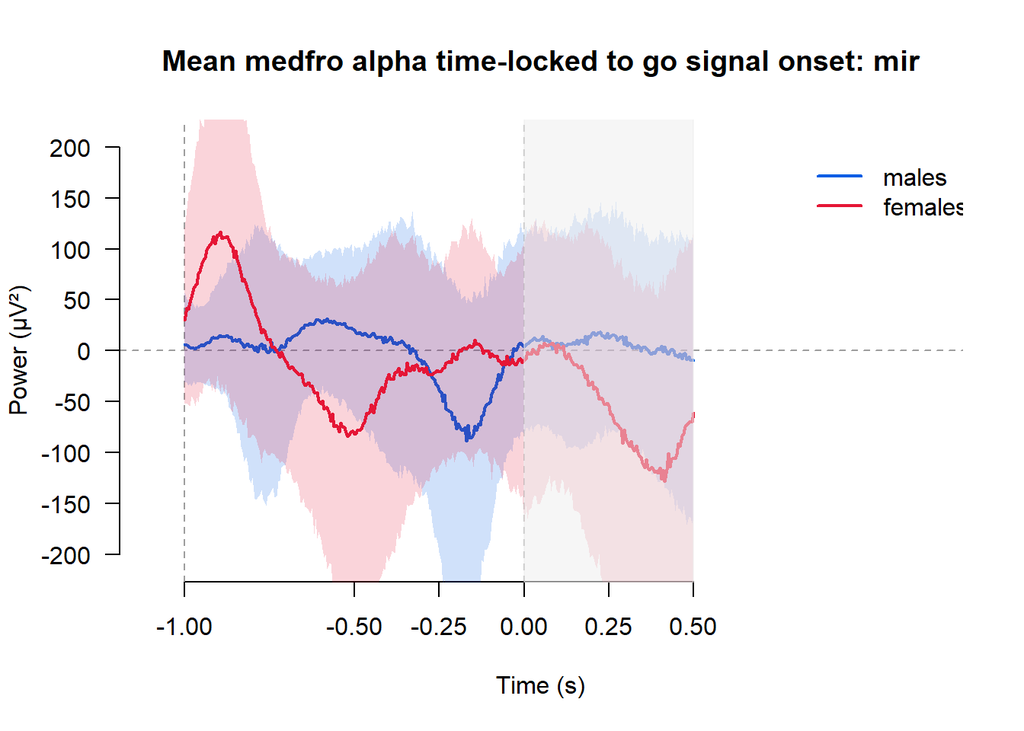

```r
plotSexPTypeTFRRPPermTestEarlyLateDiffWaves(freqs = 'alpha', roi = 'medfro')
```

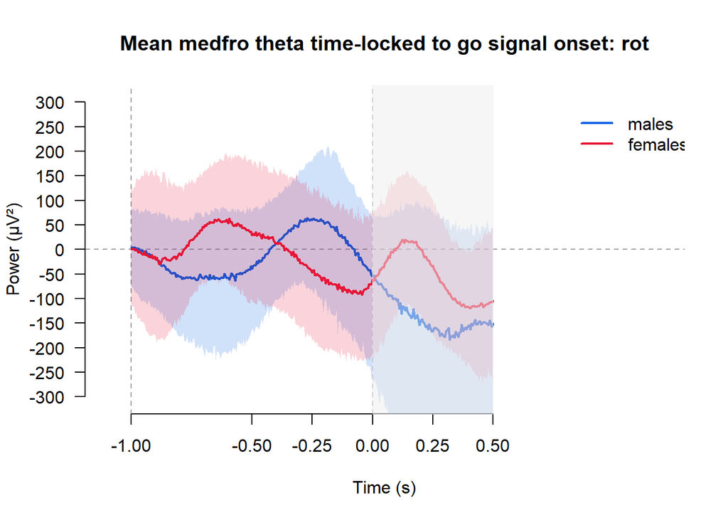

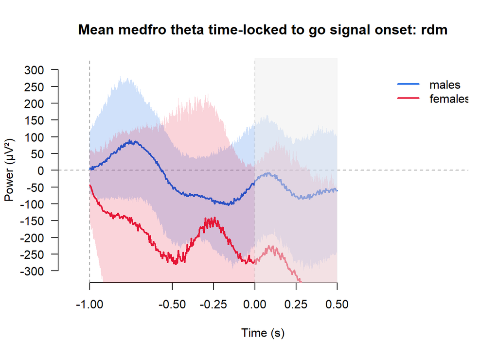

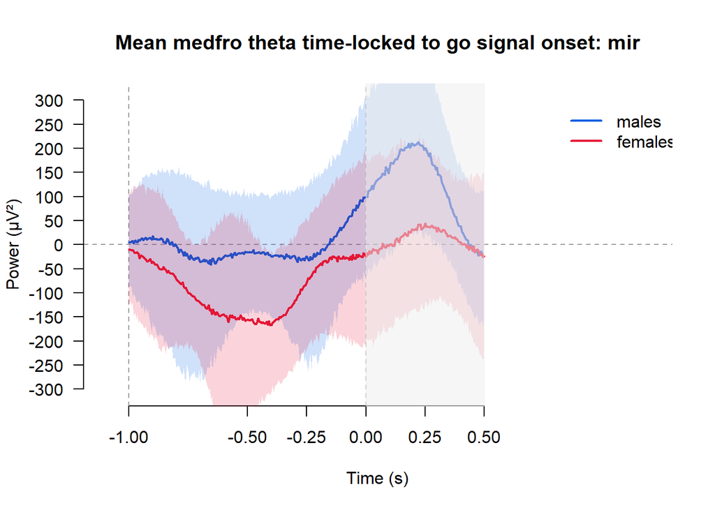

```r
plotSexPTypeTFRRPPermTestEarlyLateDiffWaves(freqs = 'theta', roi = 'medfro')
```

No significant clusters identified.

##### lateral central region

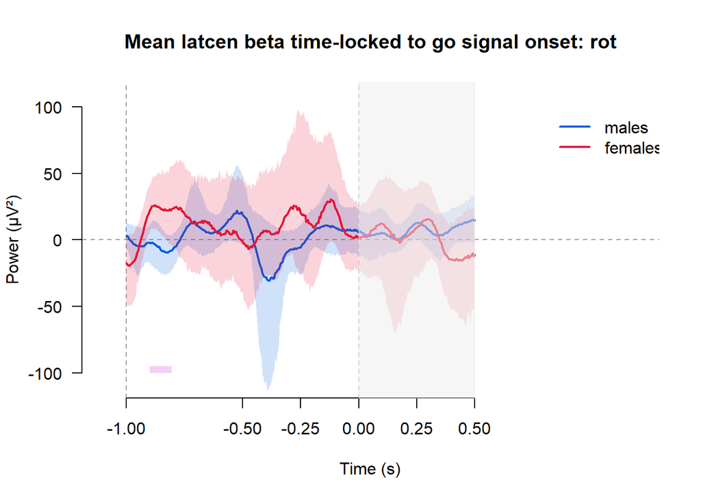

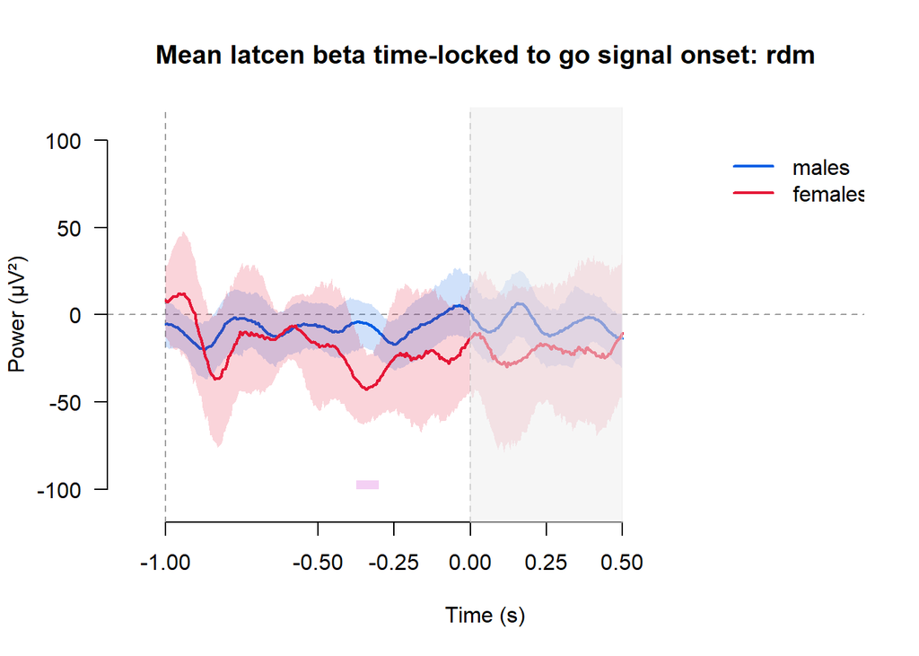

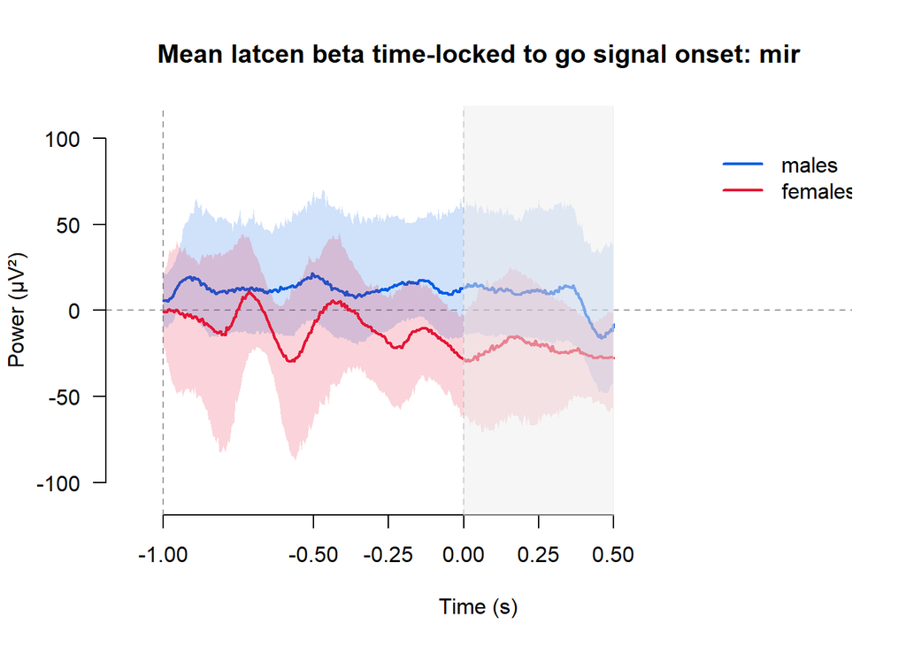

```r
plotSexPTypeTFRRPPermTestEarlyLateDiffWaves(freqs = 'beta', roi = 'latcen')
```